# VizLex: Discussing The Narrative of a Visualization

[figure not shown]

# How do we discuss written work?

# The Lexicon for Writing

A toolbox centered around the question:  
*What message(s) is the writer trying to convey to the reader?*

### Thesis, Motive, Structure, Key Words, …

Learn more here: http://www.princeton.edu/writing/university/resources/lexicon.pdf

# How do we discuss visual work?

# In General

- “Do this, not that!” method
- Learn by example
- And now… using the Visualization Lexicon!

# VizLex: Lexicon for the Visualization Narrative

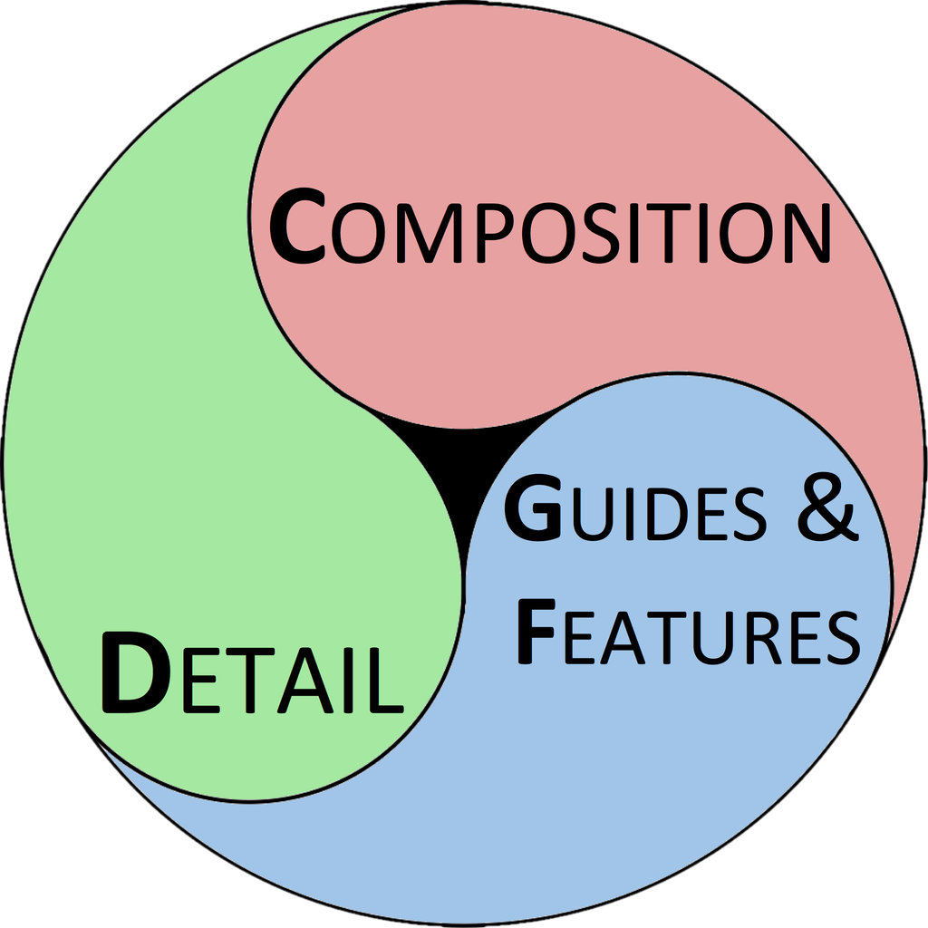

### The aim of the Visualization Lexicon is to identify how these three elements contribute to the effective communication of a desired narrative/message

# Composition

# Composition

Visual information can frequently be represented in multiple ways; the choice of how to represent this data is the **composition**

**i.e.** *What is the best way to **compose** the image in order to represent the data?*

## Different ways to compose a visualization showing the relationship between the carat of a diamond & its price

# Lineplot

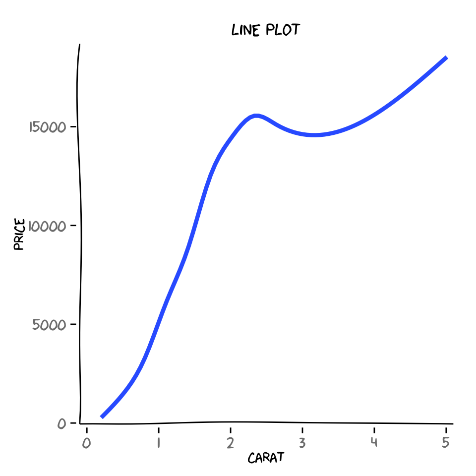

# Box Plot

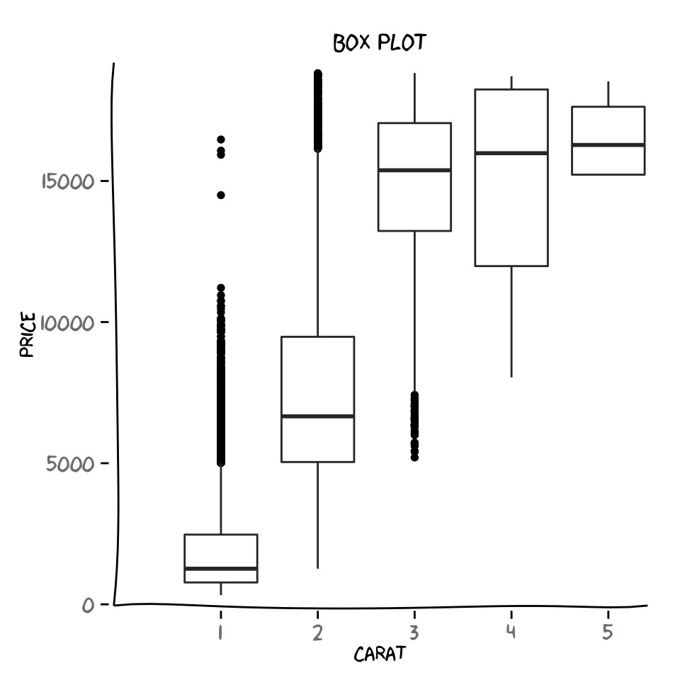

# Bar Plot

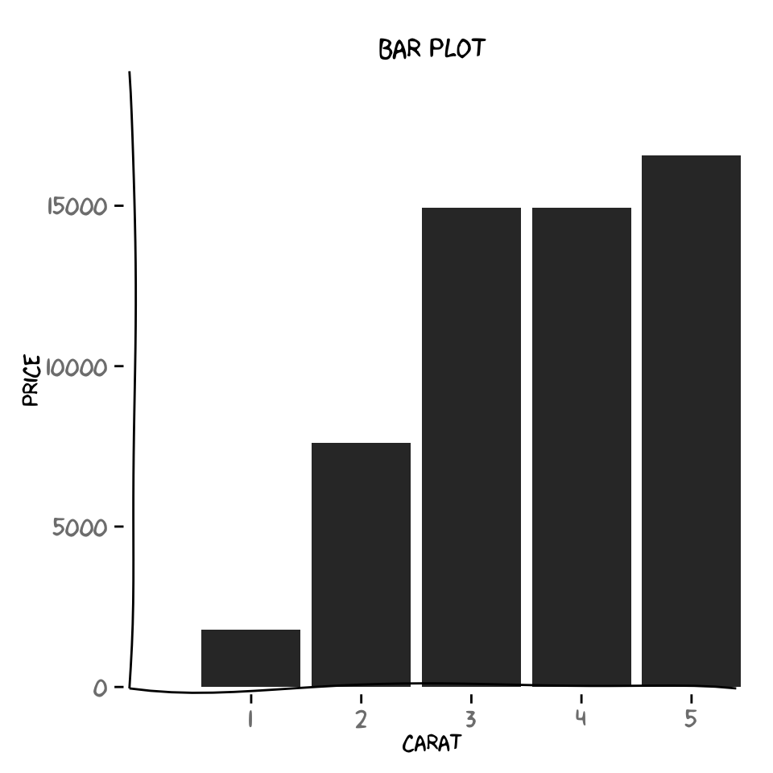

## Other Composition Examples

#### Comparing Sample Distributions

- Density Plot
- Histogram
- Box Plot

#### Showing an Image of a Landmark

Choice of Angle

Photo/Sketch/3D rendering

*.. the choice is dependent on the intended message of the visualization*

# Detail

# Detail

The detail term reflects the amount information that is presented to the viewer. It is a delicate balance aimed at providing enough information to convey the message while limiting extraneous ￼￼￼￼￼information that may detract from it.  
**i.e.** *What is the level of **detail** required to convey your message?*

## The relationship between the carat of a diamond & its price

## …same plots, more detail

# Lineplot

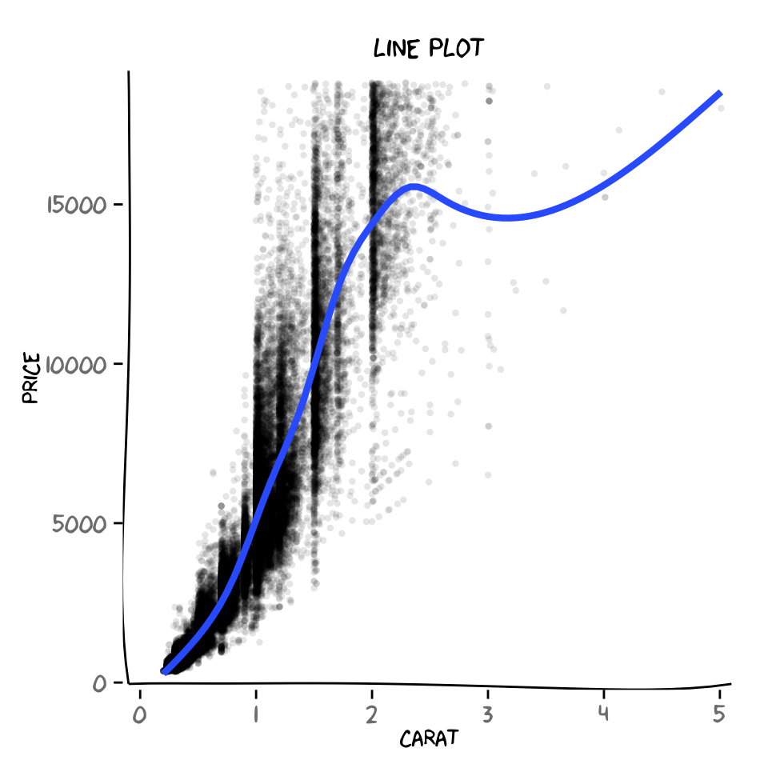

# Box Plot

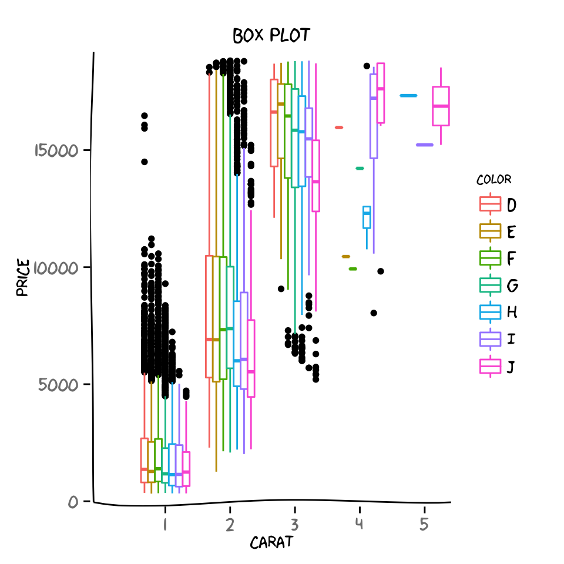

# Bar Plot

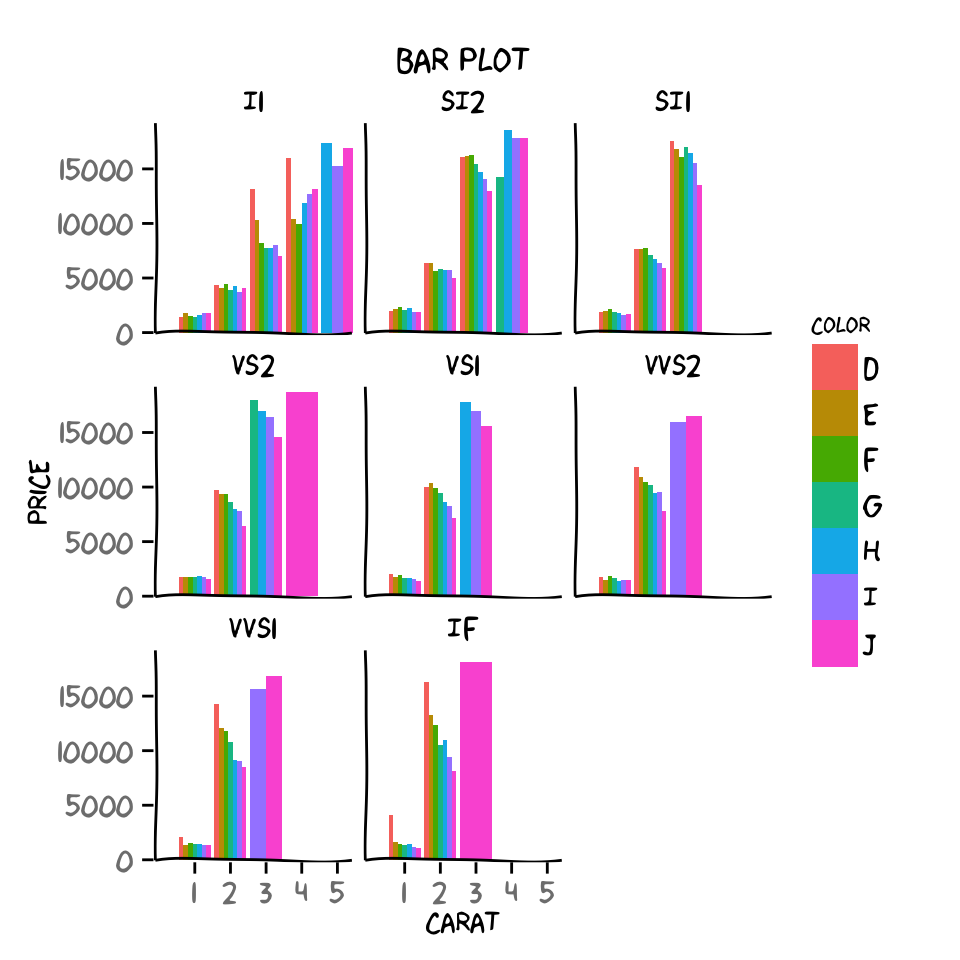

# Key Features & Guides

# Key Features & Guides

Abstractly, **key features** are the ideas present in the visualization that directly contribute to the message. **Guides** are visual cues that direct the viewers attention to the key features.  
*What features are **key** to convey the message of this visualization?*  
*How do you **guide** the viewer to the Key Features?*

## Example message: “Comedy films aren’t what they used to be, might as well watch drama!”

[figure not shown]

- In this example the most prominent key feature is the relationship between comedy & drama over time
- The elements **color, line type, axis labels, title and legend** act as guides by directing attention and providing the necessary context of this relationship

# Summary

## Using the Visualization Lexicon

1. Identify the message(s) that is(are) important to convey to the viewer/reader
2. Select the **composition** and level of **detail** that captures the relevant information to convey the message
3. List the **Key Features** of your visualization that the viewer must be aware of
4. Direct the viewer to the key features using appropriate visual **guides**
5. Iterate through steps 2-4, each time asking yourself whether your visualization effectively communicates the messages in Step 1

# VizLex Handout/Cheatsheet

The Visualization Lexicon is also available in a convenient one-pager:  
https://rawgit.com/dimagor/VizLex/master/src/VizLex-Handout.pdf